# Reading and Writing Vector Data

## Visualize written files

These maps read files from `Data/00_shared/vector_data/output_folder`. They do not reuse the features still held in memory from the write step.

The first figure compares four county outputs: the shapefile and FlatGeobuf stay in the Albers projection, the KML is in EPSG:4326, and the GPX file is the county waypoints. The next map draws those waypoints on the county shapefile. `plot_layers` reprojects the waypoints onto the shapefile CRS. The choropleth uses `SQUARE_MIL` from the written shapefile. The last figure reads six shapefiles that were converted from the GDAL samples: polygons, points, and lines.

|  | map | file | driver | features | geometry | crs |
| --- | --- | --- | --- | --- | --- | --- |
| 0 | Shapefile | ny_county/NY_County_PROJ.shp | ESRI Shapefile | 83 | Polygon | Albers |
| 1 | FlatGeobuf | ny_county/NY_County_PROJ.fgb | FlatGeobuf | 83 | Polygon | Albers |
| 2 | KML | ny_county/NY_County_PROJ.kml | LIBKML | 83 | Polygon | WGS 84 |
| 3 | GPX waypoints | ny_county/NY_County_PROJ.gpx | GPX | 83 | Point | WGS 84 |

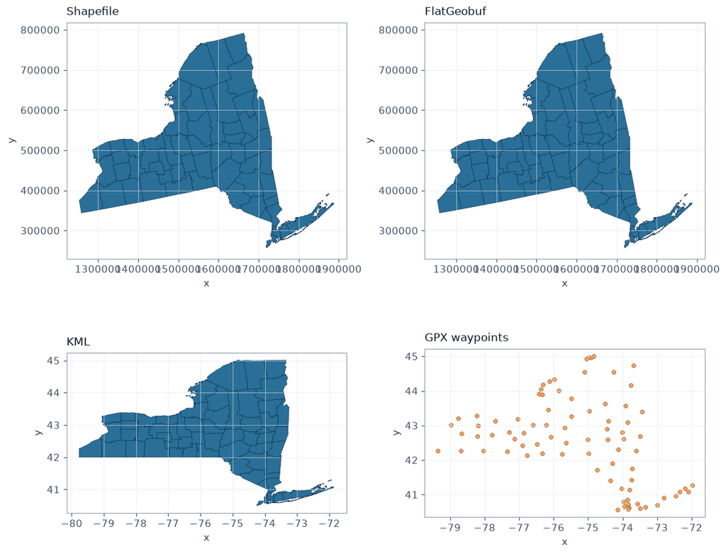

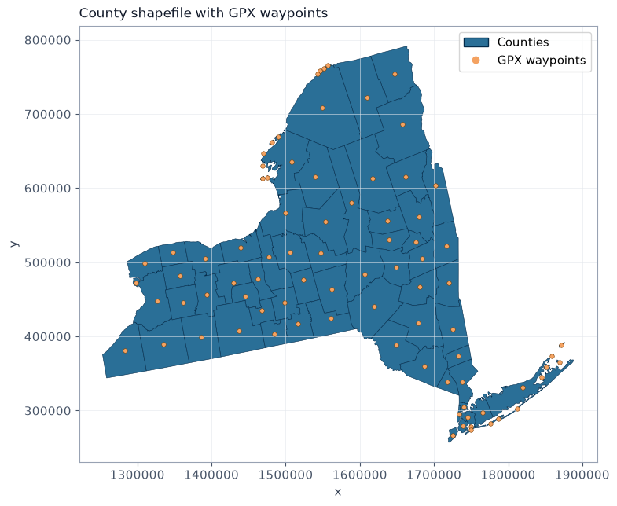

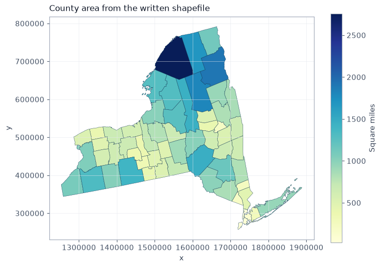

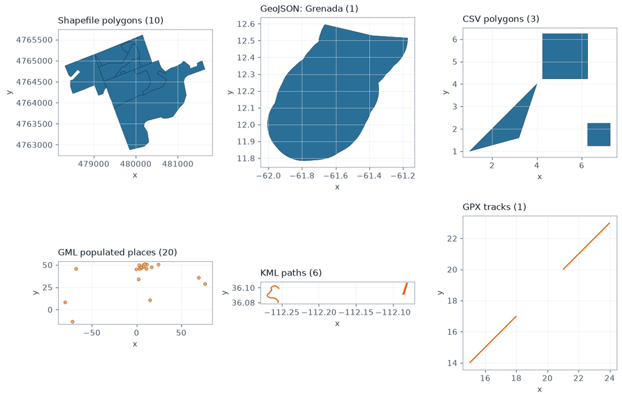

```python
# Compare written county formats side-by-side and summarize sample outputs
import matplotlib.pyplot as plt
# Statement
from geolattice.viz import plot_layer

LINE = "#E36414"
POINT = "#F4A261"
POINT_EDGE = "#7A3E00"


# Define read_output()
def read_output(path, layer=None):
    # Include Open a written file and return its GeoDataFrame, driver, and CRS name.
    """Open a written file and return its GeoDataFrame, driver, and CRS name."""
    # With read_vector_data(path, layer=layer) as dataset
    with read_vector_data(path, layer=layer) as dataset:
        # Set frame
        frame = dataset.layer.to_dataframe()
        # Set crs_name
        crs_name = None if dataset.layer.crs is None else dataset.layer.crs.name
        # Return result
        return frame, dataset.driver, crs_name


# Define draw_map()
def draw_map(frame, title, ax):
    # Set kind
    kind = frame.geometry.geom_type.iloc[0]
    # If kind in ("Point", "MultiPoint")
    if kind in ("Point", "MultiPoint"):
        # Call plot_layer()
        plot_layer(
            # Statement
            frame,
            # Statement
            title,
            # Set ax
            ax=ax,
            # Set facecolor
            facecolor=POINT,
            # Set edgecolor
            edgecolor=POINT_EDGE,
            # Set markersize
            markersize=18,
            # Set show
            show=False,
        # Close multi-line expression
        )
    # Else if kind in ("LineString", "MultiLineString", "LinearRing")
    elif kind in ("LineString", "MultiLineString", "LinearRing"):
        # Set plot_layer(frame, title, ax
        plot_layer(frame, title, ax=ax, facecolor=LINE, linewidth=1.6, show=False)
    # Otherwise
    else:
        # Set plot_layer(frame, title, ax
        plot_layer(frame, title, ax=ax, facecolor=FACE, edgecolor=EDGE, linewidth=0.4, show=False)


# Set county_views
county_views = [
    # Call function()
    ("Shapefile", COUNTY_DIR / "NY_County_PROJ.shp", None),
    # Call function()
    ("FlatGeobuf", COUNTY_DIR / "NY_County_PROJ.fgb", None),
    # Call function()
    ("KML", COUNTY_DIR / "NY_County_PROJ.kml", None),
    # Call function()
    ("GPX waypoints", COUNTY_DIR / "NY_County_PROJ.gpx", "waypoints"),
# Close multi-line expression
]

# Set county_frames
county_frames = []
# Set catalog_rows
catalog_rows = []
# Loop: title, path, layer in county_views
for title, path, layer in county_views:
    # Set frame, driver, crs_name
    frame, driver, crs_name = read_output(path, layer)
    # Call append()
    county_frames.append((title, frame))
    # Call append()
    catalog_rows.append(
        # Statement
        {
            # Statement
            "map": title,
            # Call "file": str()
            "file": str(path.relative_to(OUTPUT)),
            # Statement
            "driver": driver,
            # Call "features": len()
            "features": len(frame),
            # Statement
            "geometry": frame.geometry.geom_type.iloc[0],
            # Statement
            "crs": crs_name,
        # Close mapping or set
        }
    # Close multi-line expression
    )

# Call display()
display(pd.DataFrame(catalog_rows))

# Set fig, axes
fig, axes = plt.subplots(2, 2, figsize=(11, 9))
# Loop: ax, (title, frame) in zip(axes.ravel(), county_frames)
for ax, (title, frame) in zip(axes.ravel(), county_frames):
    # Call draw_map()
    draw_map(frame, title, ax)
# Call tight_layout()
fig.tight_layout()
# Call show()
plt.show()

# Set counties
counties = county_frames[0][1]
# Set waypoints
waypoints = county_frames[3][1]
# Call plot_layers()
plot_layers(
    # Statement
    [
        # Statement
        {"data": counties, "facecolor": FACE, "edgecolor": EDGE, "linewidth": 0.4, "label": "Counties"},
        # Statement
        {
            # Statement
            "data": waypoints,
            # Statement
            "color": POINT,
            # Statement
            "edgecolor": POINT_EDGE,
            # Statement
            "markersize": 16,
            # Include label": "GPX waypoints
            "label": "GPX waypoints",
        # Statement
        },
    # Close multi-line expression
    ],
    # Set title
    title="County shapefile with GPX waypoints",
    # Set figsize
    figsize=(8, 7),
# Close multi-line expression
)

# Call plot_layer()
plot_layer(
    # Statement
    counties,
    # Include County area from the written shapefile
    "County area from the written shapefile",
    # Set column
    column="SQUARE_MIL",
    # Set cmap
    cmap="YlGnBu",
    # Set edgecolor
    edgecolor=EDGE,
    # Set linewidth
    linewidth=0.3,
    # Set figsize
    figsize=(8, 7),
    # Set legend_kwds
    legend_kwds={"label": "Square miles", "shrink": 0.7},
# Close multi-line expression
)

# Set sample_views
sample_views = [
    # Call function()
    ("Shapefile polygons", SAMPLE_DIR / "shapefile__poly__poly.shp"),
    # Call function()
    ("GeoJSON: Grenada", SAMPLE_DIR / "geojson__grenada__grenada.shp"),
    # Call function()
    ("CSV polygons", SAMPLE_DIR / "csv__wkt__wkt.shp"),
    # Call function()
    ("GML populated places", SAMPLE_DIR / "gml__gnis_pop_110__gnis_pop.shp"),
    # Call function()
    ("KML paths", SAMPLE_DIR / "kml__samples__Paths.shp"),
    # Call function()
    ("GPX tracks", SAMPLE_DIR / "gpx__test__tracks.shp"),
# Close multi-line expression
]

# Set fig, axes
fig, axes = plt.subplots(2, 3, figsize=(12, 8))
# Loop: ax, (title, path) in zip(axes.ravel(), sample_views)
for ax, (title, path) in zip(axes.ravel(), sample_views):
    # Set frame, _, _
    frame, _, _ = read_output(path)
    # Call draw_map()
    draw_map(frame, f"{title} ({len(frame)})", ax)
# Call tight_layout()
fig.tight_layout()
# Call show()
plt.show()
```

## What was written

County outputs keep the original feature count: 83 polygons, or 83 waypoints in the GPX file. The sample shapefiles are one file per source layer and geometry type. Open any of them again with `read_vector_data` or `open_vectors_data`.

```python
# Print final write counts for county formats and sample shapefiles
print(f"County formats: {len(county_report)}")  # How many county output formats were written
print(f"County features in each file: {sorted(int(value) for value in county_report['features'].unique())}")  # Feature counts
print(f"Sample shapefiles: {len(written)} in {SAMPLE_DIR.relative_to(ROOT)}")  # GDAL-sample shapefile outputs
print(f"Sample features written: {int(written['features'].sum())}")  # Total features across sample shapefiles
```

```
County formats: 16
County features in each file: [83]
Sample shapefiles: 44 in Data/00_shared/vector_data/output_folder/gdal_as_shapefile
Sample features written: 150
```